School Suspensions Daniel Truver, Naman Agarwal, Katie Eppinger, and Emily Liu 9/28/2018

# Investigating school suspensions

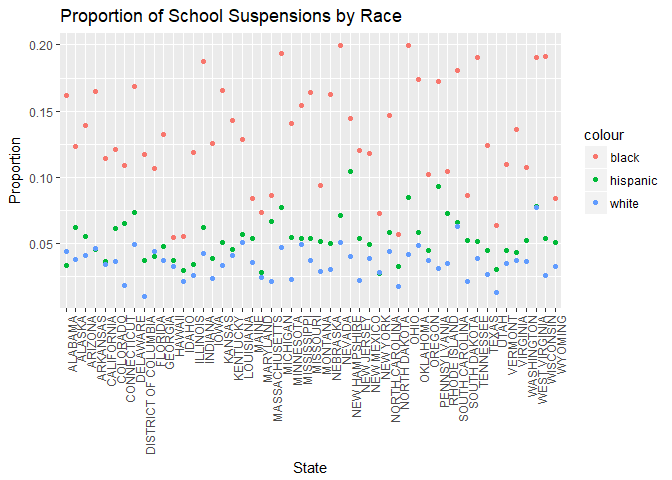

The below plot shows the difference between suspensions of black students and white students and the difference between the suspensions of Hispanic students and white students.

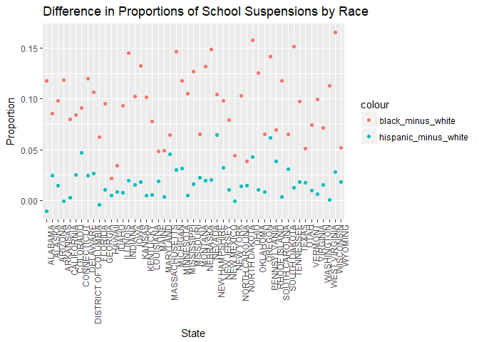

The below two graphs show the distribution of differences in suspension rates between races.

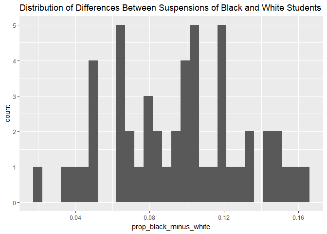

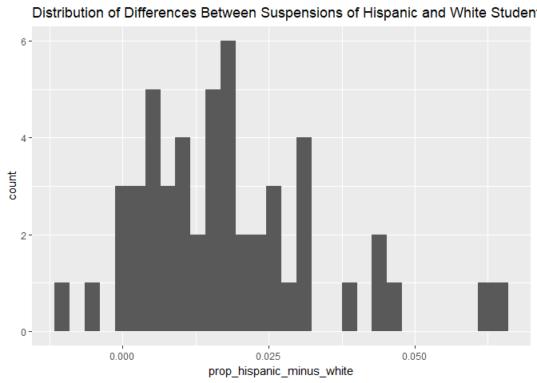

The below two lines show the outliers in our distribution labeled prop_black_minus_white (the difference in proportion between black and white student suspensions) - meaning the tails of that graph.

```
## [1] "OHIO"      "TENNESSEE" "WISCONSIN"
```

```
## [1] "HAWAII"       "IDAHO"        "NORTH DAKOTA"
```

We see that the outlier states on the max - the states with the highest difference between black and white student suspension rates - are Ohio, Tennessee, and Wisconsin, while the outlying minima states are Hawaii, Idaho, and North Dakota. We should further investigate these states to see if there are policies or systematic injustice leading to these differences.